# RNA_Seq

This notebook is just exploring RNA-Seq and genetic data and map QTLs using tensorQTLs.

This assumes that you have basic knowledge in python and takes you through some useful snippets to handle data using pandas library.

You need to have installed `pandas`, `seaborn`, `scikit-learn` and `tensorQTL`. You also need `plink` to convert the VCF to plink format. These can be easily installed using conda with `python 3.6` for example.

eQTL analysis is basically associating a genetic variant with a gene expression given that you have measured gene expression and genotypes (Arrays or by WGS) from several individuals. Usually it requires a decent sample size around 70 samples. You can still call QTLs with sample size as low as 20 samples, but that might not have statistical power. GTEx establushed a sample size of 70 to have decent results from QTL analysis.

What you need is basically:

```
A Normalized Gene expression file.

Correspondin genotypes.
```

**The basic workflow is :**

```
1. Gene expression data is normalized (TPM/FPKM etc).

2. The normalized gene expression data might have lot of variation, both technical and biological. As we are intrested only on variation caused by genetic effects, we will remove any non-genetic variation.

3. This can be achived if you have all the metadata (covariates) that might have induced variation in samples. As we usually dont have, we could just use Principle componenents that capture the variation across samples and use the PCs as covariates while calling QTLs. There are other methods that capture technical and unwanted variation like PEER.

4. Once we have normalized gene expression and PCs calculated, we can proceed for QTL association.

5. As with the gene expression, the genotypes also have some technical variation that might interfere with the QTL association. We could calculate the PCs on genotypes, referred as genetic PCs and merge with gene expression PCs and perform QTL association.
```

We will be using gene-expression and genetic data from 462 lymphoblastoid cell lines RNA-Seq data from 1000 Genomes project. Both the gene expression and genotypes ara available without dbGap access.

The data is available at https://www.ebi.ac.uk/arrayexpress/experiments/E-GEUV-1/

**Abstract says:**  
lymphoblastoid cell lines of 462 individuals from the 1000 Genomes Project, the first uniformly processed high-throughput RNA-sequencing data from multiple human populations with high-quality genome sequences

**Download the data**

Gene expression data

```
wget https://www.ebi.ac.uk/gxa/experiments-content/E-GEUV-1/resources/ExperimentDownloadSupplier.RnaSeqBaseline/tpms.tsv
```

Meta data

```
wget https://www.ebi.ac.uk/arrayexpress/files/E-GEUV-1/E-GEUV-1.sdrf.txt
```

Genotypes (For practical reasons, just get chromosome 1)

```
wget https://www.ebi.ac.uk/arrayexpress/files/E-GEUV-1/GEUVADIS.chr1.PH1PH2_465.IMPFRQFILT_BIALLELIC_PH.annotv2.genotypes.vcf.gz
```

### Import some libraries. These are the most used libraries/modules in my routine analysis

```python
import pandas as pd
import matplotlib.pyplot as plt
import seaborn as sns
import sys,os,gzip
from collections import defaultdict, Counter
```

Read the gene expression data using pandas. This is TPM normalized expression matrix.

```python
gene_ex = pd.read_csv("E-GEUV-1-query-results.tpms.tsv",
                      header = 0,
                      index_col = 0,
                      sep = "\t",
                     comment='#')
```

Lets look at the data using `head()` function of pandas DataFrame.

```python
gene_ex.head(3)
```

| Gene ID | Gene Name | British, HG00096 | British, HG00097 | British, HG00099 | British, HG00100 | British, HG00101 | British, HG00102 | British, HG00103 | British, HG00104 | British, HG00105 | ... | Yoruba, NA19214 | Yoruba, NA19222 | Yoruba, NA19223 | Yoruba, NA19225 | Yoruba, NA19235 | Yoruba, NA19236 | Yoruba, NA19247 | Yoruba, NA19248 | Yoruba, NA19256 | Yoruba, NA19257 |
| --- | --- | --- | --- | --- | --- | --- | --- | --- | --- | --- | --- | --- | --- | --- | --- | --- | --- | --- | --- | --- | --- |
| ENSG00000000003 | TSPAN6 | 0.1 | 0.1 | 0.1 | NaN | NaN | 0.1 | 0.1 | 0.2 | 0.2 | ... | 0.1 | 0.1 | 2.0 | 0.3 | 0.2 | 0.4 | 0.2 | 0.2 | 0.1 | NaN |
| ENSG00000000005 | TNMD | NaN | NaN | NaN | NaN | NaN | NaN | NaN | NaN | NaN | ... | NaN | NaN | NaN | NaN | NaN | NaN | NaN | NaN | NaN | NaN |
| ENSG00000000419 | DPM1 | 166.0 | 122.0 | 158.0 | 143.0 | 159.0 | 192.0 | 217.0 | 147.0 | 186.0 | ... | 161.0 | 116.0 | 162.0 | 110.0 | 131.0 | 198.0 | 196.0 | 145.0 | 153.0 | 87.0 |

3 rows × 463 columns

We can see that some values are `NaN` i.e they are empty. We could just fill them with `0`

Pandas provides a function `fillna` that can replace NaN values with given value. This can be anythin including a string.

We use `inplace=True` so that the existing dataframe is modified instead of `returning` a new dataframe.

```python
gene_ex.fillna(0, inplace=True)
```

Lets inspect the dataframe again using `head()`

```python
gene_ex.head(3)
```

| Gene ID | Gene Name | British, HG00096 | British, HG00097 | British, HG00099 | British, HG00100 | British, HG00101 | British, HG00102 | British, HG00103 | British, HG00104 | British, HG00105 | ... | Yoruba, NA19214 | Yoruba, NA19222 | Yoruba, NA19223 | Yoruba, NA19225 | Yoruba, NA19235 | Yoruba, NA19236 | Yoruba, NA19247 | Yoruba, NA19248 | Yoruba, NA19256 | Yoruba, NA19257 |
| --- | --- | --- | --- | --- | --- | --- | --- | --- | --- | --- | --- | --- | --- | --- | --- | --- | --- | --- | --- | --- | --- |
| ENSG00000000003 | TSPAN6 | 0.1 | 0.1 | 0.1 | 0.0 | 0.0 | 0.1 | 0.1 | 0.2 | 0.2 | ... | 0.1 | 0.1 | 2.0 | 0.3 | 0.2 | 0.4 | 0.2 | 0.2 | 0.1 | 0.0 |
| ENSG00000000005 | TNMD | 0.0 | 0.0 | 0.0 | 0.0 | 0.0 | 0.0 | 0.0 | 0.0 | 0.0 | ... | 0.0 | 0.0 | 0.0 | 0.0 | 0.0 | 0.0 | 0.0 | 0.0 | 0.0 | 0.0 |
| ENSG00000000419 | DPM1 | 166.0 | 122.0 | 158.0 | 143.0 | 159.0 | 192.0 | 217.0 | 147.0 | 186.0 | ... | 161.0 | 116.0 | 162.0 | 110.0 | 131.0 | 198.0 | 196.0 | 145.0 | 153.0 | 87.0 |

3 rows × 463 columns

Now we could see that the `NaN` are replaced by `0.0`

Lets drop the `Gene Name` column to make the dataframe more like a gene x samples matrix. We will use the pandas in-built `drop()` method and `inplace=True` so that the original dataframe is modified.

Before doing that, lets create a dictionary of geneIDs and corresponding geneNames. Might be useful later.

```python
GeneID_GeneNames = {}

for geneID, geneName in gene_ex["Gene Name"].items():
    GeneID_GeneNames[geneID] = geneName
```

Lets drop the `Gene Name` column

```python
gene_ex.drop(columns=["Gene Name"], inplace = True)
```

We could also notice that the samples names contains the ethnicity information.

We could just get rid of this and keep the sampleID only. As we will be loading the meta-data later, we could map sampleID to ethnicity.

We will use pythons `list comprehensions`. Basically, for each column name, we will `split()` function to split the column name by comma, then take the sampleID and then `strip()` any white space. Before doing that, lets see a small examples.

```python
# make a example list
li = ["British, HG00096","British, HG00097"]

print(li)

# lets split the list elements
for element in li:
    print(element.split(","))

print("Now print only the sample ID")

for element in li:
    print(element.split(",")[1])

print("Now stript the white space")

for element in li:
    print(element.split(",")[1].strip())
```

```
['British, HG00096', 'British, HG00097']
['British', ' HG00096']
['British', ' HG00097']
Now print only the sample ID
 HG00096
 HG00097
Now stript the white space
HG00096
HG00097
```

Lets apply the above procedure using a `list comprehension` to all column names. The column names are stored in `columns` attribute.

```python
gene_ex.columns = [x.split(",")[1].strip() for x in gene_ex.columns]
```

Lets inspect the dataframe. Now you will notice that we have only sampleIDs

```python
gene_ex.head(3)
```

| Gene ID | HG00096 | HG00097 | HG00099 | HG00100 | HG00101 | HG00102 | HG00103 | HG00104 | HG00105 | HG00106 | ... | NA19214 | NA19222 | NA19223 | NA19225 | NA19235 | NA19236 | NA19247 | NA19248 | NA19256 | NA19257 |
| --- | --- | --- | --- | --- | --- | --- | --- | --- | --- | --- | --- | --- | --- | --- | --- | --- | --- | --- | --- | --- | --- |
| ENSG00000000003 | 0.1 | 0.1 | 0.1 | 0.0 | 0.0 | 0.1 | 0.1 | 0.2 | 0.2 | 0.1 | ... | 0.1 | 0.1 | 2.0 | 0.3 | 0.2 | 0.4 | 0.2 | 0.2 | 0.1 | 0.0 |
| ENSG00000000005 | 0.0 | 0.0 | 0.0 | 0.0 | 0.0 | 0.0 | 0.0 | 0.0 | 0.0 | 0.0 | ... | 0.0 | 0.0 | 0.0 | 0.0 | 0.0 | 0.0 | 0.0 | 0.0 | 0.0 | 0.0 |
| ENSG00000000419 | 166.0 | 122.0 | 158.0 | 143.0 | 159.0 | 192.0 | 217.0 | 147.0 | 186.0 | 184.0 | ... | 161.0 | 116.0 | 162.0 | 110.0 | 131.0 | 198.0 | 196.0 | 145.0 | 153.0 | 87.0 |

3 rows × 462 columns

Lets inspect the size of the dataframe using `shape`. This tells us the number of rows (genes) and number of columns (samples).

```python
gene_ex.shape
```

```
(50194, 462)
```

Seems like there are around 50000 genes in the dataframe. This is biologically doesnt make sense as there will be around ~15000 genes expressed in any given tissue at any stage.

So lets remove genes that are not expressed in atleast 10% of the samples with a minimum of 0.1 TMP. This also helps us to clean the data a bit as we are removing very very lowly expressed genes that could be just noise.

We will use a simple pandas expression to remove them.

```python
pct_samples = 10
n_samples_threshold = (gene_ex.shape[1]*pct_samples/100)

gene_ex_filt = gene_ex[(gene_ex>0.1).sum(axis=1)>=n_samples_threshold]
```

Now we have a new data frame `gene_ex_filt` after removing the lowly expressed genes. Lets see the shape of the dataframe.

```python
gene_ex_filt.shape
```

```
(28250, 462)
```

By using a very basic filter, we removed almost 22000 genes that are expressed at very low levels

Lets read the metadata and see how many samples are how many features are there.

```python
gene_ex_metaData = pd.read_csv("E-GEUV-1.sdrf.txt", header = 0, index_col = 0, sep ="\t")
gene_ex_metaData.shape
```

```
(924, 36)
```

The gene expression dataframe seems to have only 462 samples, but the metadata contains twice the number of samples.

So lets inspect the metadata

```python
gene_ex_metaData.head(3)
```

| Source Name | Comment[ENA_SAMPLE] | Characteristics[organism] | Term Source REF | Term Accession Number | Characteristics[individual] | Characteristics[sex] | Characteristics[developmental stage] | Characteristics[organism part] | Characteristics[cell type] | Characteristics[cell line] | ... | Technology Type | Comment[ENA_EXPERIMENT] | Comment[READ_INDEX_1_BASE_COORD] | Protocol REF.3 | Scan Name | Comment[SUBMITTED_FILE_NAME] | Comment[ENA_RUN] | Comment[FASTQ_URI] | Factor Value[ancestry category] | Factor Value[individual] |
| --- | --- | --- | --- | --- | --- | --- | --- | --- | --- | --- | --- | --- | --- | --- | --- | --- | --- | --- | --- | --- | --- |
| HG00096 | ERS185276 | Homo sapiens | NCBI Taxonomy | 9606 | HG00096 | male | adult | blood | B cell | lymphoblastoid cell line | ... | high_throughput_sequencing | ERX163134 | 76 | P-GEUV-6 | HG00096.1.M_111124_6_1.fastq.gz | HG00096.1.M_111124_6_1.fastq.gz | ERR188040 | ftp://ftp.sra.ebi.ac.uk/vol1/fastq/ERR188/ERR1... | British | HG00096 |
| HG00096 | ERS185276 | Homo sapiens | NCBI Taxonomy | 9606 | HG00096 | male | adult | blood | B cell | lymphoblastoid cell line | ... | high_throughput_sequencing | ERX163134 | 76 | P-GEUV-6 | HG00096.1.M_111124_6_2.fastq.gz | HG00096.1.M_111124_6_2.fastq.gz | ERR188040 | ftp://ftp.sra.ebi.ac.uk/vol1/fastq/ERR188/ERR1... | British | HG00096 |
| HG00097 | ERS185206 | Homo sapiens | NCBI Taxonomy | 9606 | HG00097 | female | adult | blood | B cell | lymphoblastoid cell line | ... | high_throughput_sequencing | ERX162845 | 76 | P-GEUV-6 | HG00097.7.M_120219_2_1.fastq.gz | HG00097.7.M_120219_2_1.fastq.gz | ERR188231 | ftp://ftp.sra.ebi.ac.uk/vol1/fastq/ERR188/ERR1... | British | HG00097 |

3 rows × 36 columns

From the index, seems like each sample is represented twice. If you scroll across the dataframe, you will notice that its because the read-1 and read-2 are represented in seperate rows.

So lets remove those columns that represents information about read1 and read2, as its redundant information. we will use the `drop()` method with `inplace=True`

```python
gene_ex_metaData.drop(columns=["Comment[SUBMITTED_FILE_NAME]","Comment[ENA_RUN]","Comment[FASTQ_URI]","Scan Name"], inplace = True)
```

Once we removed those columns, lets remove the duplicate rows with `drop_duplicates()` method and see the shape of the dataset.

```python
gene_ex_metaData = gene_ex_metaData.drop_duplicates(keep="first")
gene_ex_metaData.shape
```

```
(462, 32)
```

Now we could see that the number of samples in metadata matches with the number of samples in gene expression.

Let make sure that sample names matches. so lets re-organize the metadata in a similar order as that of gene expression dataframe. We will use `loc` for metadata as the sampleIDs are rownames (index)

```python
gene_ex_metaData = gene_ex_metaData.loc[gene_ex.columns]
```

```python
(gene_ex_metaData.index == gene_ex.columns).all()
```

```
True
```

#### Lets explore the gene expression data now. First lets look at the PCA.

1. we need to import he PCA function from sci-kit learn.
2. Define number of PCs we want to calculate
3. Apply the PCA function using `fit`

```python
from sklearn.decomposition import PCA
pca = PCA(n_components=15)
gene_ex_filt_pca = pca.fit(gene_ex_filt)
```

Lets see what are the components that pca.fit returned using the `dir()` method of python.

`dir()` method returns all the functions and attributes that are associated with a given object type. You could test with `dir(str)` to know functions/attributes assciated with a string object or `dir(int)` or `dir(pd.DataFrame)` etc

```python
print(dir(gene_ex_filt_pca))
```

```
['__abstractmethods__', '__class__', '__delattr__', '__dict__', '__dir__', '__doc__', '__eq__', '__format__', '__ge__', '__getattribute__', '__getstate__', '__gt__', '__hash__', '__init__', '__init_subclass__', '__le__', '__lt__', '__module__', '__ne__', '__new__', '__reduce__', '__reduce_ex__', '__…
```

So we can see that the `gene_ex_filt_pca` has different information like `n_features_`, `n_samples_`, `n_components_` etc etc.

Most important thing for us is `components_` that stores PCs.

```python
gene_ex_filt_pca.components_
```

```
array([[ 0.04343216,  0.04594167,  0.04586485, ...,  0.04691622,
         0.03180503,  0.040228  ],
       [-0.01168997, -0.00073494, -0.01909536, ...,  0.03756973,
        -0.00587569,  0.06077362],
       [ 0.02518342,  0.06336839, -0.00296203, ..., -0.05569223,
        -0.0005004 , -0.03669231],
       ...,
       [-0.00861657,  0.03253982, -0.00632418, ..., -0.06666697,
         0.06024863,  0.08782403],
       [-0.01533937,  0.02760053,  0.12505185, ...,  0.04407694,
         0.01962084,  0.00520635],
       [ 0.02571753,  0.019377  , -0.06779408, ..., -0.05969701,
         0.04007226,  0.01425574]])
```

It seems like its a numpy array, so lets convert it back to pandas dataframe by assignig PC numbers and sampleIDs from `gene_ex_filt`

```python
gene_ex_filt_PCs = pd.DataFrame(gene_ex_filt_pca.components_, columns=gene_ex_filt.columns, index=["PC_"+str(x) for x in range(1,16)]).T
```

```python
gene_ex_filt_PCs.head(3)
```

|  | PC_1 | PC_2 | PC_3 | PC_4 | PC_5 | PC_6 | PC_7 | PC_8 | PC_9 | PC_10 | PC_11 | PC_12 | PC_13 | PC_14 | PC_15 |
| --- | --- | --- | --- | --- | --- | --- | --- | --- | --- | --- | --- | --- | --- | --- | --- |
| HG00096 | 0.043432 | -0.011690 | 0.025183 | -0.003881 | -0.037718 | -0.019014 | -0.009849 | -0.038982 | 0.007621 | -0.017875 | 0.044806 | 0.013256 | -0.008617 | -0.015339 | 0.025718 |
| HG00097 | 0.045942 | -0.000735 | 0.063368 | 0.019918 | 0.006851 | 0.002455 | 0.005563 | -0.044977 | -0.050277 | 0.016590 | 0.002688 | -0.001588 | 0.032540 | 0.027601 | 0.019377 |
| HG00099 | 0.045865 | -0.019095 | -0.002962 | -0.032325 | 0.191919 | 0.097597 | -0.032630 | 0.051308 | 0.218681 | -0.096276 | 0.098449 | 0.041658 | -0.006324 | 0.125052 | -0.067794 |

Now lets plot PC1 vs PC2 using pandas default `scatter` plot function.

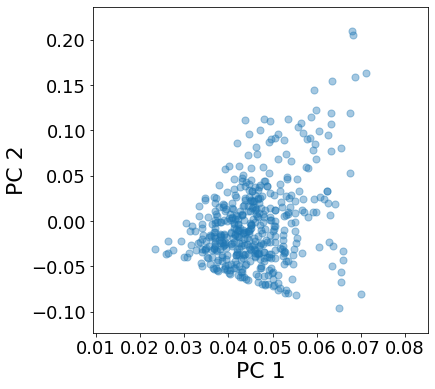

```python
gene_ex_filt_PCs.plot.scatter(x="PC_1", y="PC_2", figsize=(6,6), s = 50, alpha=0.4)
plt.xticks(size=18)
plt.yticks(size=18)
plt.xlabel("PC 1", size = 22)
plt.ylabel("PC 2", size = 22)
```

Seems like there is not much structure in the gene expression data. Lets color the samples based on meta information.

Before doing that, it would be easier if we merge the PCs `gene_ex_filt_PCs` with the metadata `gene_ex_metaData`. We will use pandas `merge()` function to merge two dataframes that have matching index/rownames.

```python
gene_ex_filt_PCs_and_meta = gene_ex_filt_PCs.merge(gene_ex_metaData, right_index = True, left_index = True)
```

```python
gene_ex_filt_PCs_and_meta.head(3)
```

|  | PC_1 | PC_2 | PC_3 | PC_4 | PC_5 | PC_6 | PC_7 | PC_8 | PC_9 | PC_10 | ... | Comment[NOMINAL_SDEV] | Protocol REF.2 | Performer | Assay Name | Technology Type | Comment[ENA_EXPERIMENT] | Comment[READ_INDEX_1_BASE_COORD] | Protocol REF.3 | Factor Value[ancestry category] | Factor Value[individual] |
| --- | --- | --- | --- | --- | --- | --- | --- | --- | --- | --- | --- | --- | --- | --- | --- | --- | --- | --- | --- | --- | --- |
| HG00096 | 0.043432 | -0.011690 | 0.025183 | -0.003881 | -0.037718 | -0.019014 | -0.009849 | -0.038982 | 0.007621 | -0.017875 | ... | 0 | P-GEUV-5 | UNIGE | HG00096.1.M_111124_6 | high_throughput_sequencing | ERX163134 | 76 | P-GEUV-6 | British | HG00096 |
| HG00097 | 0.045942 | -0.000735 | 0.063368 | 0.019918 | 0.006851 | 0.002455 | 0.005563 | -0.044977 | -0.050277 | 0.016590 | ... | 0 | P-GEUV-5 | LUMC | HG00097.7.M_120219_2 | high_throughput_sequencing | ERX162845 | 76 | P-GEUV-6 | British | HG00097 |
| HG00099 | 0.045865 | -0.019095 | -0.002962 | -0.032325 | 0.191919 | 0.097597 | -0.032630 | 0.051308 | 0.218681 | -0.096276 | ... | 0 | P-GEUV-5 | HMGU | HG00099.5.M_120131_3 | high_throughput_sequencing | ERX162743 | 76 | P-GEUV-6 | British | HG00099 |

3 rows × 47 columns

Lets use `seaborn` library, plot the same scatter plot but color(`hue`) the samples by ethnicity.

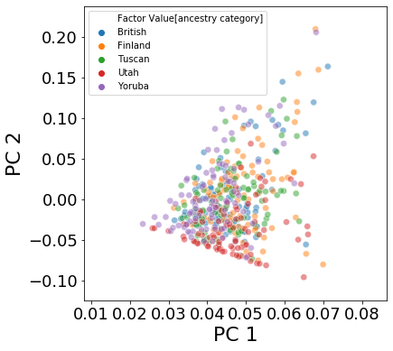

```python
plt.figure(figsize=(6,6))
sns.scatterplot(x="PC_1", y="PC_2", s=50, alpha=0.5, hue = "Factor Value[ancestry category]", data = gene_ex_filt_PCs_and_meta)
plt.xticks(size=18)
plt.yticks(size=18)
plt.xlabel("PC 1", size = 22)
plt.ylabel("PC 2", size = 22)
```

Doesn't seem like a drastic structure in the data based on ethnicity, but lets look at only `Yoruba` and `Utah` samples.

We will first subset only `Yoruba` and `Utah` samples into a `_tmp` dataframe then plot again.

```
(180, 47)
```

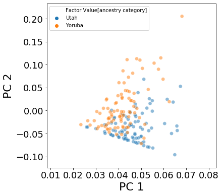

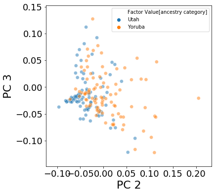

```python
gene_ex_filt_PCs_and_meta_tmp = gene_ex_filt_PCs_and_meta[(gene_ex_filt_PCs_and_meta["Factor Value[ancestry category]"]=="Yoruba") | (gene_ex_filt_PCs_and_meta["Factor Value[ancestry category]"]=="Utah")]
print(gene_ex_filt_PCs_and_meta_tmp.shape, "\n\n")

plt.figure(figsize=(6,6))
sns.scatterplot(x="PC_1", y="PC_2", hue = "Factor Value[ancestry category]", s=50, alpha=0.5,data = gene_ex_filt_PCs_and_meta_tmp)
plt.xticks(size=18)
plt.yticks(size=18)
plt.xlabel("PC 1", size = 22)
plt.ylabel("PC 2", size = 22)
plt.show()


plt.figure(figsize=(6,6))
sns.scatterplot(x="PC_2", y="PC_3", hue = "Factor Value[ancestry category]", s=50, alpha=0.5, data = gene_ex_filt_PCs_and_meta_tmp)
plt.xticks(size=18)
plt.yticks(size=18)
plt.xlabel("PC 2", size = 22)
plt.ylabel("PC 3", size = 22)
```

Seems like there is some structure there based on ethnicity. Lets try couple of other categories.

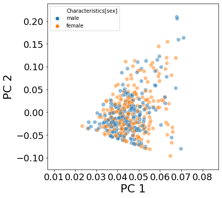

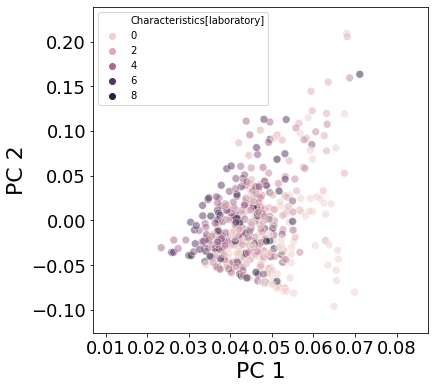

```python
plt.figure(figsize=(6,6))
sns.scatterplot(x="PC_1", y="PC_2", s=60, alpha=0.5, hue = "Characteristics[sex]", data = gene_ex_filt_PCs_and_meta)
plt.xticks(size=18)
plt.yticks(size=18)
plt.xlabel("PC 1", size = 22)
plt.ylabel("PC 2", size = 22)
plt.show()


plt.figure(figsize=(6,6))
sns.scatterplot(x="PC_1", y="PC_2", s=60, alpha=0.5, hue = "Characteristics[laboratory]", data = gene_ex_filt_PCs_and_meta)
plt.xticks(size=18)
plt.yticks(size=18)
plt.xlabel("PC 1", size = 22)
plt.ylabel("PC 2", size = 22)
plt.show()
```

As we dont have much information about the samples, we could not explore much in terms of their variation. If we have RIN values, sequencing batch , sequencing center etc, we might correlate the PCs with meta data as they tend to explain most of the technical variation in RNA-Seq data sets.

### Lets get the gencode v19 annotations as mentioned in original manuscript.

Lets download the annotations and used a simple awk command to get the TSS information

```
wget ftp://ftp.ebi.ac.uk/pub/databases/gencode/Gencode_human/release_19/gencode.v19.annotation.gtf.gz

zcat  gencode.v19.annotation.gtf.gz | grep -v "^#" | awk -v OFS="\t" '{ if ($3=="gene") print $1,$4,$5,$7,$10 }' | awk -F"\t" -v OFS="\t" '{ gsub("\"","",$5); gsub(";","",$5); if ($4=="+") {print $1,$2,$2,$5,".",$4} else { print $1,$3,$3,$5,".",$4}}' | sort -k1,1 -k2,2n | uniq > gencode.v19.annotation.gtf.tss.bed
```

### Read the TSS file and append TSS information to gene expression file.

```python
gencode_v19_tss = pd.read_csv("gencode.v19.annotation.gtf.tss.bed", header = None, index_col=None, sep = "\t")
gencode_v19_tss.columns = ["chr","start","end","geneID","score(NA)","strand"]
gencode_v19_tss.drop(columns = ["score(NA)","strand"], inplace = True)
```

```python
gencode_v19_tss.head(3)
```

|  | chr | start | end | geneID |
| --- | --- | --- | --- | --- |
| 0 | chr1 | 11869 | 11869 | ENSG00000223972.4 |
| 1 | chr1 | 29554 | 29554 | ENSG00000243485.2 |
| 2 | chr1 | 29806 | 29806 | ENSG00000227232.4 |

We could use this informaion to map QTLs. Before that we need to make sure that the geneIDs are identical in both the dataframes. So lets take out the extra info and check if they are still unique

```python
print(len([x.split(".")[0] for x in gencode_v19_tss["geneID"]]))

print("Unique geneIDs after stripping")
print(len(set([x.split(".")[0] for x in gencode_v19_tss["geneID"]])))
```

```
57820
Unique geneIDs after stripping
57820
```

Lets update the geneIDs with the stripped names i.e `ENSG00000227232.4 --> ENSG00000227232`

```python
gencode_v19_tss["geneID"]  = [x.split(".")[0] for x in gencode_v19_tss["geneID"]]
gencode_v19_tss.index = gencode_v19_tss["geneID"]
```

```python
gencode_v19_tss.head(3)
```

| geneID | chr | start | end | geneID |
| --- | --- | --- | --- | --- |
| ENSG00000223972 | chr1 | 11869 | 11869 | ENSG00000223972 |
| ENSG00000243485 | chr1 | 29554 | 29554 | ENSG00000243485 |
| ENSG00000227232 | chr1 | 29806 | 29806 | ENSG00000227232 |

```python
gene_ex_filt_wTSS = gencode_v19_tss.merge(gene_ex_filt, right_index = True, left_index = True, how="inner")
gene_ex_filt_wTSS["chr"] = [x.replace("chr","") for x in gene_ex_filt_wTSS["chr"]]
gene_ex_filt_wTSS.rename(columns={"start": "tss"}, inplace=True)
```

```python
gene_ex_filt_wTSS.head(3)
```

|  | chr | tss | end | geneID | HG00096 | HG00097 | HG00099 | HG00100 | HG00101 | HG00102 | ... | NA19214 | NA19222 | NA19223 | NA19225 | NA19235 | NA19236 | NA19247 | NA19248 | NA19256 | NA19257 |
| --- | --- | --- | --- | --- | --- | --- | --- | --- | --- | --- | --- | --- | --- | --- | --- | --- | --- | --- | --- | --- | --- |
| ENSG00000227232 | 1 | 29806 | 29806 | ENSG00000227232 | 0.3 | 0.2 | 0.0 | 0.0 | 0.0 | 0.0 | ... | 0.5 | 0.4 | 0.3 | 0.0 | 0.0 | 1.0 | 0.4 | 0.4 | 0.5 | 0.6 |
| ENSG00000268903 | 1 | 135895 | 135895 | ENSG00000268903 | 1.0 | 0.3 | 0.0 | 0.0 | 2.0 | 0.0 | ... | 1.0 | 0.0 | 0.0 | 1.0 | 3.0 | 1.0 | 0.0 | 0.0 | 0.4 | 0.4 |
| ENSG00000269981 | 1 | 137965 | 137965 | ENSG00000269981 | 1.0 | 0.0 | 0.0 | 0.0 | 5.0 | 2.0 | ... | 0.0 | 0.0 | 0.0 | 0.0 | 0.0 | 2.0 | 0.0 | 1.0 | 2.0 | 1.0 |

3 rows × 466 columns

```python
gene_ex_filt.shape
```

```
(28250, 462)
```

```python
gene_ex_filt_wTSS.shape
```

```
(26246, 466)
```

Seems like there are around 2000 genes in the expression file that do not have corresponding geneIDs matching with the TSS file. This can happen if the authors do not provide exactly how they process the data, including minor details.

```python
_sample_names = open("sampleIDs.txt","w")

for sample in gene_ex_filt.columns:
    _sample_names.write(sample)
    _sample_names.write("\n")

_sample_names.close()
```

Lets process the vcf file we downloaded. Subset the vcf files to the samples from sampleIDs.txt and keep a MAF cutoff 0f 5% and remove missing genotypes

```
plink --memory 20000 --geno 0.01 --maf 0.05 --keep-fam sampleIDs.txt --vcf GEUVADIS.chr1.PH1PH2_465.IMPFRQFILT_BIALLELIC_PH.annotv2.genotypes.vcf.gz --recode vcf-iid --out geuvadis-chr1

plink --make-bed --vcf geuvadis-chr1.vcf --out geuvadis_chr1
```

Use tensorQTL functions to load genotypes.

```python
import torch
import tensorqtl
from tensorqtl import genotypeio, cis, trans
```

```python
plink_prefix_path = 'geuvadis_chr1'
pr = genotypeio.PlinkReader(plink_prefix_path)
genotype_df = pr.load_genotypes()
variant_df = pr.bim.set_index('snp')[['chrom', 'pos']]
```

The above snippet read the genotypes and created a dataframe of genotypes across samples, `genotype_df` and another dataframe of variant positions, `variant_df`

```python
# Lets sort the samples in genotype_df to match with the gene expression matrix
genotype_df = genotype_df[gene_ex_filt.columns]
```

```python
genotype_df.head(2)
```

| iid snp | HG00096 | HG00097 | HG00099 | HG00100 | HG00101 | HG00102 | HG00103 | HG00104 | HG00105 | HG00106 | ... | NA19214 | NA19222 | NA19223 | NA19225 | NA19235 | NA19236 | NA19247 | NA19248 | NA19256 | NA19257 |
| --- | --- | --- | --- | --- | --- | --- | --- | --- | --- | --- | --- | --- | --- | --- | --- | --- | --- | --- | --- | --- | --- |
| snp_1_52238 | 0 | 1 | 2 | 0 | 0 | 0 | 0 | 0 | 0 | 1 | ... | 0 | 2 | 0 | 1 | 1 | 1 | 0 | 1 | 0 | 1 |
| snp_1_55164 | 0 | 1 | 1 | 0 | 0 | 0 | 0 | 0 | 0 | 0 | ... | 0 | 2 | 0 | 1 | 1 | 1 | 0 | 1 | 0 | 1 |

2 rows × 462 columns

```python
genotype_df.shape
```

```
(524759, 462)
```

```python
variant_df.head(2)
```

| snp | chrom | pos |
| --- | --- | --- |
| snp_1_52238 | 1 | 52238 |
| snp_1_55164 | 1 | 55164 |

Lets subset the gene expression matrix to chromosome 1 and then split the data frame to gene expression values `gene_ex_filt_wTSS_chr1_pheno_df` and tss positions, `gene_ex_filt_wTSS_chr1_pos_df`, similar to that of genotype_df and genotype_pos.

This may look a bit circular, to merge gene expression with TSS file and then split. You can follow any method that you prefer.

```python
gene_ex_filt_wTSS_chr1 = gene_ex_filt_wTSS[gene_ex_filt_wTSS["chr"]=="1"]
```

```python
gene_ex_filt_wTSS_chr1_pos_df = gene_ex_filt_wTSS_chr1[["chr","tss","end"]]
gene_ex_filt_wTSS_chr1_pheno_df = gene_ex_filt_wTSS_chr1.drop(columns=["geneID","chr","tss","end"])
```

```python
cis_df = cis.map_cis(genotype_df, variant_df,
                gene_ex_filt_wTSS_chr1_pheno_df,
                gene_ex_filt_wTSS_chr1_pos_df,
               covariates_df=gene_ex_filt_PCs)

cis_df.sort_values("pval_beta", inplace=True)
```

```python
cis_df.head()
```

[output not shown]

```python
#Lets plot some QTLs.
#Lets define a function to plot the QTLs. This is very basic function with hardcoded dataframes from this notebook. This needs to be improved to make ir general purpose

def plotQTLs(GeneID, Genotype):
    plt.figure(figsize=(6,6))
    _tmp_gene_ex = pd.DataFrame(gene_ex_filt_wTSS_chr1_pheno_df.loc[GeneID])
    _tmp_genotypes = pd.DataFrame(genotype_df.loc[Genotype])
    _tmp_df = _tmp_gene_ex.merge(_tmp_genotypes, left_index = True, right_index = True)
    _tmp_df.columns = ["GeneEx","Genotype"]
    sns.boxplot(x="Genotype", y="GeneEx", data = _tmp_df)
    sns.swarmplot(x="Genotype", y="GeneEx", data = _tmp_df)
    plt.xlabel("Genotype", size=22)
    plt.ylabel("Gene Expression(TPM) \n"+GeneID, size=22)
    plt.xticks(size=22)
    plt.yticks(size=22)
```

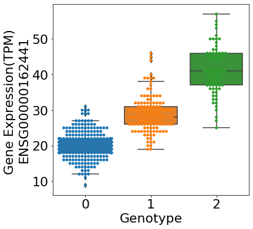

```python
plotQTLs("ENSG00000162441","snp_1_10003320")
```